# Exploratory Analysis

## Project title

NBA Clutch Predictor

### Authors

Altti Koskinen

### Date

Spring 2024

### Abstract

Consider that in the world of the NBA, clutch moments can define a player and decide if a team wins. This is important because understanding how players perform under pressure and when they need to the most can show a players true skills, and impact on how a game ends. Accordingly, we plan to create a tool that can use and analyze player cltuch shot data, allowing people to predict and see who could make the next defining play.

### Keywords

NBA; clutch scoring; player; team; predictor

### Introduction

This project aims to analyze and understand NBA player and team clutch performance using data from clutch free throw attempts/percent made compared to overall free throw attempts/percent made, clutch shots taken, made and percentage. Clutch moments in basketball games are high pressure and show how players deal with that pressure and use their skills. Some research questions would be looking at how clutch situations impact free throws and field goals made. How much does a players clutch factor play into winning games. Does clutch shot efficiency rise with more attempts. All these questions are important because they can enhance peoples appreciation for players skills when they matter most and how pressure impacts performance efficiency in general.

### Related Work

This article by [Inpredictable](https://www.inpredictable.com/2014/03/measuring-clutch-play-in-nba.html) looked into how to measure clutch shots and what counts as one. They explain how the NBA term for clutch shot is very broad and includes shots that definitely are much less clutch. > “A three point basket with your team down by two and five seconds to play is far more clutch than a two pointer with 3:50 on the clock and up by three”

This next article by [Fadeaway World](https://fadeawayworld.net/ranking-the-20-most-clutch-players-in-nba-history-michael-jordan-kobe-bryant-and-larry-bird-were-masters-late-in-games) look at the most clutch players of all time ranking them in a top 20 list. In addition they showed each players most clutch moments as well. They define clutch as: > “the final shot to give their team the lead or tie the game in the final 60 seconds in the fourth quarter or overtime periods”

This last article by [The Athletic](https://theathletic.com/1142773/2019/08/20/the-clutch-factor-analyzing-hero-shots-in-the-nba/) looked more at team specific clutch factors and how better teams will still be more likely to win no matter if the game comes down to the final minute or not. The author did point out better team win less in close games than in not close ones. > “As mentioned above, teams that were good at winning non-clutch games were generally better at winning these very close ‘clutch’ games than were worse teams, but late/close situations evened the odds considerably”

### The Dataset

Where did you find the data? Please include a link to the data source

[The Pudding Clutch Data Set](https://github.com/the-pudding/data/tree/master/clutch)

Who collected the data?

The Pudding

How was the data collected or generated?

The data was collected on all the clutch shots taken since the 1996-97 season until last season

Why was the data collected?

To quantify clutchness in a number

How many features (columns) are in the data?

There are 11 features in the data set

What, if any, ethical questions or questions of power do you need to consider when working with this data?

There does not seem to be any questions of power to consider.

What are possible limitations or problems with this data? (at least 200 words)

Some possible limitations with this data set could be exactly what defines a clutch shot, for example how many possessions back still count as well as how much time left still counts. This makes it more difficult to understand and use the data more accurately. In addition, the clutch shots are grouped by players and there is no grouping for year, which can make it difficult to do anything with the data that involves seasons. Also another problem is that only players who have attempted a clutch shot are recorded which makes it hard to assume what a player that hasn’t attempted one yet could do. Finally another problem is that the spread of clutch shots attempted is very wide which can make predictions for some players much better for someone with hundreds of clutch attempts versus someone with only a handful.

### Implications

If the research questions end up getting answered, the possible implications include a better insight into which players should take the clutch shots in the future, how often clutch shot efficiency will actually impact the game and if playing the final minutes safe is better when looking at accuracy based on a shots difficulty. Finally, technologists could find the best player to give the ball to in real time if a basketball game starts to become close, allowing real time strategy changes to align with the data. In general the implications would contribute to a more data and informed approach to basketball.

### Limitations & Challenges

Some important variable that might be important down the line could be missing. For exmaple looking back to the limitations of the data set section, there is no grouping for year which can make understanding and analyzing the data impossible in some situations. Also using the data to create create a predictor might prove to be difficult and very inaccurate if incorrect steps or decisions get made.

### Summary Information

###### Loading Libraries

```
## [1] "Total clutch shots taken: 39903"
```

```
## [1] "Clutch shot percentage: 48.2742184856828"
```

```
## [1] "Clutch free throw percentage: 77.1965215723815"
```

```
## [1] "Adjusted shot percentage based on difficulty: 1.38440887291598"
```

```
## [1] "Highest impact: Kobe Bryant, 0.0583213282247765"
```

### Table

Table of summary information

This table reveals the averages, highest, and lowest number for all notable variables for clutch shots and games.

```
##       pid             bbrid               name             fta_clutch
##  Min.   :     56   Length:287         Length:287         Min.   :  4.00
##  1st Qu.:   2200   Class :character   Class :character   1st Qu.: 18.00
##  Median : 101162   Mode  :character   Mode  :character   Median : 27.00
##  Mean   : 246061                                         Mean   : 37.71
##  3rd Qu.: 202694                                         3rd Qu.: 47.00
##  Max.   :1629639                                         Max.   :253.00
##  ft_pct_clutch    total_clutch_shots   pct_clutch      ft_pct_all
##  Min.   : 33.33   Min.   : 50.0      Min.   :31.40   Min.   :41.46
##  1st Qu.: 70.04   1st Qu.: 68.0      1st Qu.:44.27   1st Qu.:74.73
##  Median : 78.57   Median :104.0      Median :48.24   Median :79.69
##  Mean   : 77.20   Mean   :139.0      Mean   :48.27   Mean   :78.25
##  3rd Qu.: 84.50   3rd Qu.:169.5      3rd Qu.:52.19   3rd Qu.:83.19
##  Max.   :100.00   Max.   :745.0      Max.   :70.91   Max.   :90.53
##      gp_all       pct_clutch_adjusted swg_made_per_game
##  Min.   : 267.0   Min.   :-18.620     Min.   :0.00410
##  1st Qu.: 642.0   1st Qu.: -3.234     1st Qu.:0.01109
##  Median : 833.0   Median :  1.443     Median :0.01616
##  Mean   : 847.6   Mean   :  1.384     Mean   :0.01933
##  3rd Qu.:1021.0   3rd Qu.:  5.574     3rd Qu.:0.02437
##  Max.   :1703.0   Max.   : 23.489     Max.   :0.05832
```

### Chart 1

This graph shows players based on clutch shots attempted and their completion percentages. I chose this chart because it shows some of the most efficient players in the league in clutch situations as well as where players with the most clutch attempts stand.

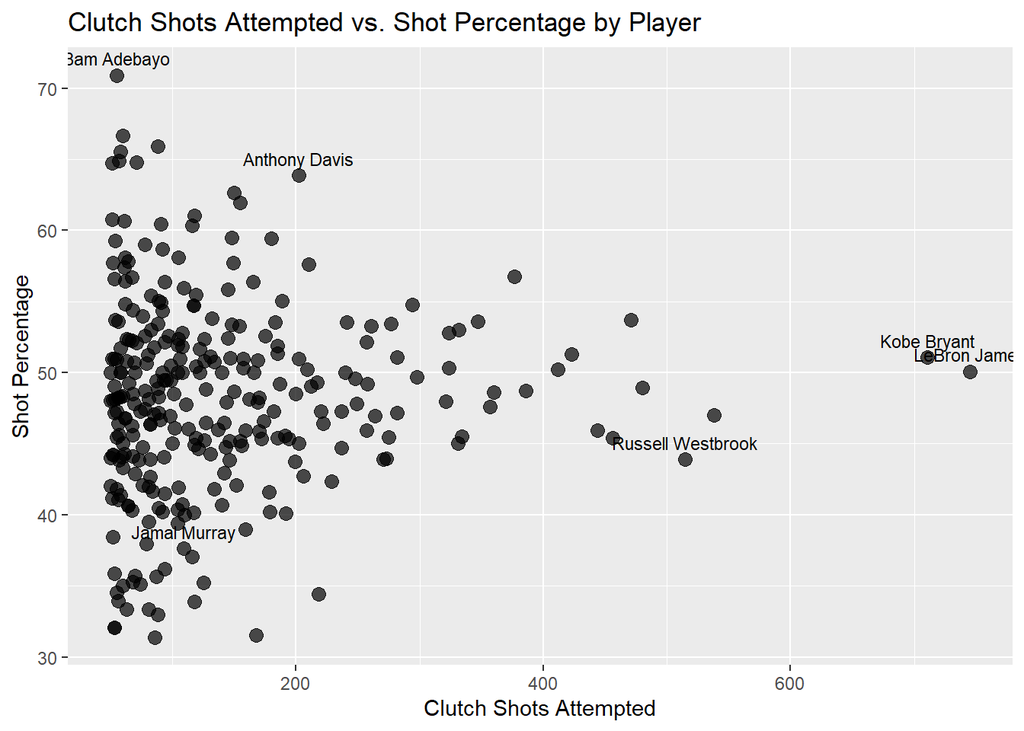

### Chart 2

This histogram shows Where players fall for impact on a team. This number is found looking at the swing(affect on team win probability based on a shot going in or not) makes per game. This graph shows where most players in the league fall as well as some of the super stars who are able to make game deciding shots when necessary.

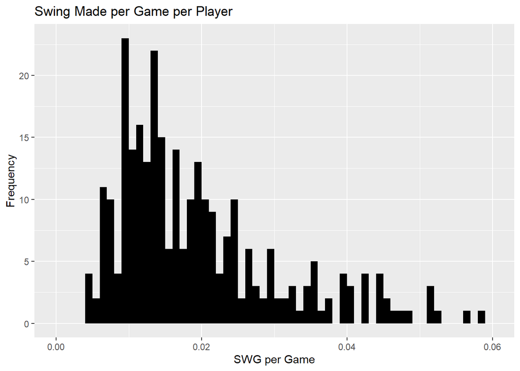

### Chart 3

This scatter plot displays how games played and experience does not end up having too much of an impact on making difficult shots in high pressure situations. “Clutch” players will fall into the positives for making difficult shots regardless of games played. The distribution is about equal for a positive or negative adjusted percentage.

[figure not shown]